# ICA 7 POCOCK

Let us take the probability distribution we worked with in the previous 2 ICA’s, p(x) = 1/8 * x, where x is between 0 and 4. Recall that the cdf is given by F(x) = 1/16 * x2. a. Calculate (on paper) the inverse of the cdf function. b. Create a variable un which is 1,000,000 simulations of the uniform variable on the unit segment.

```r
un <- runif(1000000)
```

```r
un_4 <- (runif(1000000)^3)/8
```

3. Put this un variable into the inverse cdf, generating a new variable un_4.
4. Plot a histogram of un_4. Does the shape correspond to the pdf of the original function?

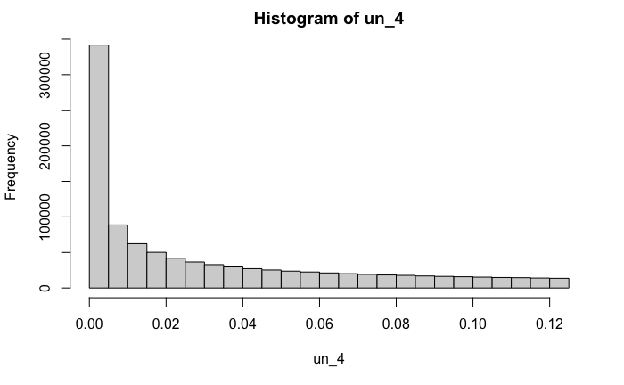

```r
hist(un_4)
```

```r
mean((runif(1000000)^3)/8)
```

```
[1] 0.03126959
```

```r
mean(((runif(1000000)^3)/8)^2)
```

```
[1] 0.002230134
```

2. You are running a manufacturing plant which can produce 120,000 units per month. You are told that the expected demand for next month is uncertain; it is normally distributed with mean 100,000 and standard deviation 25,000. Each unit sold generates $20 in profit.
1. What is the expected number of units sold? (no calculation required)
2. What is the profit associated with the expected number of units sold? ($20 x the answer in (a))

```r
20*100000
```

```
[1] 2e+06
```

3. Generate 1,000,000 simulations of demand with rnorm. Store it in a variable called demand.

```r
demand <- rnorm(1000000,100000,25000)
```

```r
sales_vol = pmax(demand, 120000)
mean(sales_vol)
```

```
[1] 123019
```

5. Calculate for the simulations the total profit. Call it profit.

```r
profit <- rnorm(1000000,100000*20,25000*20)
mean(profit)
```

```
[1] 2000427
```

6. What is the average of the profit? How does it compare to the profit of the average (answer in (b))? Discuss and explain the difference?